# The Impact of Cursor Adoption on Python Velocity

Borusyak et al. (2021) Difference-in-Differences Imputation — Model A

2026-08-02 22:29:21 CDT

# 1 Overview

This report was generated automatically by **run-x-a06** in the same execution that estimated the Borusyak imputation models. It follows the presentation logic of the original `DiffInDiffBorusyak.Rmd` while retaining the Python-focused sample construction and quality-control decisions established in run-x-a01 through run-x-a05.

The analysis contains **1954 repository-month observations**, including **63 treatment repositories** and **104 matched control repositories**. The first stage uses **1591 untreated observations**, and the static ATT averages **363 post-adoption observations**.

# 2 Analysis Design

## 2.1 Treatment and timing

- Treatment is an absorbing intent-to-treat indicator beginning at the first observed Cursor adoption month.
- Calendar time and adoption time use the consecutive indices `time_index` and `event_index`.
- Legacy month-specific fields such as `cursor`, `is_treatment`, `post_event`, `lead_*`, and `lag_*` are retained only for audit.
- Standard errors are clustered by `repo_id`.

## 2.2 Model A first stage

~ log_age + ncloc + log_contributors + log_stars + log_issues | repo_id + time_index

## 2.3 Reported estimands

- Static ATT: all post-adoption observations.
- Dynamic ATT: event months 0 through +6.
- Placebo pretrends: event months -6 through -2.
- Event month -1 is the omitted reference period.

# 3 Sample and Quality Control

Analysis sample and QC summary

| Section | Metric | Value | Note |
| --- | --- | --- | --- |
| Input | Rows | 1954 |  |
| Input | Repositories | 167 |  |
| Input | Treatment Rows | 914 |  |
| Input | Control Rows | 1040 |  |
| Input | Treatment Repositories | 63 |  |
| Input | Control Repositories | 104 |  |
| Sample | Untreated First Stage Rows | 1591 | Controls plus not-yet-treated treatment observations. |
| Sample | Treated Static Rows | 363 | All event-time 0 and later observations. |
| Sample | Treated Dynamic 0 to Max Rows | 343 | Event times 0 through 6. |
| Qc | Duplicate Repo Time Rows | 0 |  |
| Qc | Normalized Timing Errors | 0 |  |
| Qc | Missing Model Rows | 0 |  |
| Qc | Legacy Mismatch Rows | 11 | Audit only; normalized absorbing timing is authoritative. |
| Qc | Legacy Mismatch Repositories | 3 |  |

The 11 legacy-flag mismatches are expected audit findings. The models use normalized absorbing treatment timing, and there are no normalized timing errors, duplicate repository-months, or missing Model A fields.

# 4 Aggregate Treatment Effects

Static Borusyak ATT estimates

| Outcome | Estimate | Std. Error | 95% CI | p-value | Significant | Exp. coefficient change (%) |
| --- | --- | --- | --- | --- | --- | --- |
| Commits | 0.055 | 0.112 | [-0.165, 0.274] | 0.625 | No | 5.6 |
| Lines Added | 0.647 | 0.259 | [0.140, 1.155] | 0.012 | Yes | 91.0 |

The static ATT for **Commits** is 0.055 (95% CI [-0.165, 0.274], p=0.625), and is not statistically significant.  
The static ATT for **Lines Added** is 0.647 (95% CI [0.140, 1.155], p=0.012), and is statistically significant.  
The exponentiated changes are descriptive transformations on the `log1p` outcome scale rather than exact percentage changes in every repository-month.

# 5 Dynamic Treatment Effects

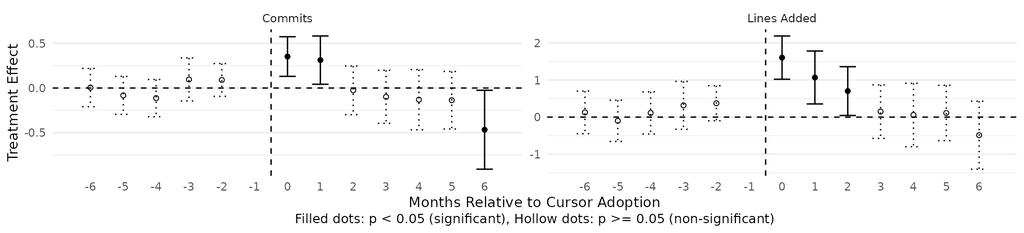

The event-study figure follows the original implementation: filled points have p < 0.05, hollow points have p >= 0.05, and event month -1 is omitted.

Post-adoption dynamic treatment effects

| Outcome | Event Month | Estimate | Std. Error | 95% CI | p-value | Significant | Support Repositories |
| --- | --- | --- | --- | --- | --- | --- | --- |
| Commits | 0 | 0.353 | 0.113 | [0.131, 0.575] | 0.002 | Yes | 62 |
| Commits | +1 | 0.313 | 0.138 | [0.042, 0.583] | 0.024 | Yes | 59 |
| Commits | +2 | -0.026 | 0.139 | [-0.298, 0.246] | 0.852 | No | 56 |
| Commits | +3 | -0.099 | 0.152 | [-0.396, 0.199] | 0.515 | No | 54 |
| Commits | +4 | -0.131 | 0.172 | [-0.468, 0.207] | 0.448 | No | 52 |
| Commits | +5 | -0.137 | 0.164 | [-0.459, 0.186] | 0.406 | No | 40 |
| Commits | +6 | -0.467 | 0.226 | [-0.910, -0.025] | 0.038 | Yes | 20 |
| Lines Added | 0 | 1.604 | 0.298 | [1.020, 2.187] | <0.001 | Yes | 62 |
| Lines Added | +1 | 1.068 | 0.364 | [0.355, 1.781] | 0.003 | Yes | 59 |
| Lines Added | +2 | 0.702 | 0.335 | [0.045, 1.359] | 0.036 | Yes | 56 |
| Lines Added | +3 | 0.149 | 0.368 | [-0.573, 0.870] | 0.687 | No | 54 |
| Lines Added | +4 | 0.057 | 0.436 | [-0.798, 0.912] | 0.895 | No | 52 |
| Lines Added | +5 | 0.111 | 0.381 | [-0.634, 0.857] | 0.770 | No | 40 |
| Lines Added | +6 | -0.487 | 0.468 | [-1.404, 0.430] | 0.298 | No | 20 |

# 6 Pretrend Checks

Original-Rmd-aligned pretrend summary

| Outcome | Placebo Periods | Terms Checked | All 95% CIs Include Zero | Periods Excluding Zero | Minimum p-value |
| --- | --- | --- | --- | --- | --- |
| Commits | -6,-5,-4,-3,-2 | 5 | Yes |  | 0.288 |
| Lines Added | -6,-5,-4,-3,-2 | 5 | Yes |  | 0.121 |

Package-native placebo coefficients

| Outcome | Event Month | Estimate | Std. Error | 95% CI | p-value | CI Includes Zero | Support Repositories |
| --- | --- | --- | --- | --- | --- | --- | --- |
| Commits | -6 | 0.005 | 0.110 | [-0.210, 0.220] | 0.963 | Yes | 43 |
| Commits | -5 | -0.082 | 0.108 | [-0.295, 0.130] | 0.447 | Yes | 45 |
| Commits | -4 | -0.113 | 0.106 | [-0.321, 0.095] | 0.288 | Yes | 45 |
| Commits | -3 | 0.096 | 0.123 | [-0.145, 0.337] | 0.434 | Yes | 49 |
| Commits | -2 | 0.090 | 0.094 | [-0.093, 0.274] | 0.334 | Yes | 52 |
| Lines Added | -6 | 0.126 | 0.293 | [-0.448, 0.701] | 0.666 | Yes | 43 |
| Lines Added | -5 | -0.100 | 0.284 | [-0.656, 0.457] | 0.726 | Yes | 45 |
| Lines Added | -4 | 0.112 | 0.290 | [-0.456, 0.681] | 0.698 | Yes | 45 |
| Lines Added | -3 | 0.317 | 0.330 | [-0.329, 0.963] | 0.336 | Yes | 49 |
| Lines Added | -2 | 0.373 | 0.241 | [-0.099, 0.845] | 0.121 | Yes | 52 |

# 7 Event-Time and Cohort Support

Treatment support in the reported event window

| Event Month | Treatment Rows | Treatment Repositories | Period Type |
| --- | --- | --- | --- |
| -6 | 43 | 43 | placebo pretrend |
| -5 | 45 | 45 | placebo pretrend |
| -4 | 45 | 45 | placebo pretrend |
| -3 | 49 | 49 | placebo pretrend |
| -2 | 52 | 52 | placebo pretrend |
| -1 | 63 | 63 | reference |
| 0 | 62 | 62 | post treatment |
| +1 | 59 | 59 | post treatment |
| +2 | 56 | 56 | post treatment |
| +3 | 54 | 54 | post treatment |
| +4 | 52 | 52 | post treatment |
| +5 | 40 | 40 | post treatment |
| +6 | 20 | 20 | post treatment |

Adoption-cohort support

| Adoption Cohort | Treatment Repositories | Pre-treatment Rows | Post-treatment Rows | Dynamic 0:+6 Rows | Available Event Range |
| --- | --- | --- | --- | --- | --- |
| 2024-09 | 2 | 14 | 17 | 12 | -8 to +11 |
| 2024-10 | 1 | 9 | 11 | 7 | -9 to +10 |
| 2024-11 | 2 | 20 | 11 | 11 | -10 to +5 |
| 2024-12 | 6 | 24 | 38 | 33 | -9 to +8 |
| 2025-01 | 11 | 89 | 69 | 63 | -12 to +7 |
| 2025-02 | 11 | 113 | 67 | 67 | -13 to +6 |
| 2025-03 | 30 | 282 | 150 | 150 | -14 to +5 |

# 8 Diagnostics and Legacy-Flag Audit

Model diagnostics

| Outcome | Model | Status | Runtime (seconds) | Warnings | Result Terms | Details |
| --- | --- | --- | --- | --- | --- | --- |
| log_commits | first_stage | success | 0.032 | 0 | 5 | nobs=1591; prediction_na_all=0; prediction_na_treated=0 |
| log_commits | static | success | 0.471 | 0 | 1 |  |
| log_commits | dynamic | success | 0.086 | 0 | 12 | horizon_argument=-6,-5,-4,-3,-2,-1,0,1,2,3,4,5,6; pretrends=-6,-5,-4,-3,-2; reference=-1 omitted |
| log_commits | pretrend_original_rmd_check | success | 0.000 | 0 | 5 | all_ci_include_zero=TRUE; periods_excluding_zero=none |
| log_lines_added | first_stage | success | 0.017 | 0 | 5 | nobs=1591; prediction_na_all=0; prediction_na_treated=0 |
| log_lines_added | static | success | 0.041 | 0 | 1 |  |
| log_lines_added | dynamic | success | 0.079 | 0 | 12 | horizon_argument=-6,-5,-4,-3,-2,-1,0,1,2,3,4,5,6; pretrends=-6,-5,-4,-3,-2; reference=-1 omitted |
| log_lines_added | pretrend_original_rmd_check | success | 0.000 | 0 | 5 | all_ci_include_zero=TRUE; periods_excluding_zero=none |

Legacy monthly-flag mismatches retained for audit only

| Repository | Mismatch Rows | First Mismatch Month | Last Mismatch Month |
| --- | --- | --- | --- |
| LearningCircuit/local-deep-research | 5 | 2025-04 | 2025-08 |
| allthingslinux/tux | 2 | 2025-07 | 2025-08 |
| whiteducksoftware/flock | 4 | 2025-05 | 2025-08 |

# 9 Reproducibility Metadata

Run metadata

| Field | Value |
| --- | --- |
| Implementation Version | v7 |
| Run Started | 2026-08-02 22:29:19 CDT |
| Run Finished | 2026-08-02 22:29:20 CDT |
| Runtime Seconds | 1.33011484146118 |
| Input File | /home/user1-system12/project-workspace/ai_code_complexity_study_python/ai-code-complexity-study/repo_x01/run-x-a05/velocity_did_panel_model_a.csv |
| Input Sha256 | c52dd1de53e67b99371ac226e5957f2ca7e27356f24e071e2590836162a05534 |
| Script Path | proc_script_x01/did_borusyak_velocity_model_a.R |
| Script Sha256 | 195412879b044bb229d9fb767161c2a5eca119853cfb2ec565dd1cb1a46f09a0 |
| r Version | R version 4.3.3 (2024-02-29) |
| Platform | x86_64-conda-linux-gnu |
| Hostname | OISSE-IST173C01 |
| Didimputation Version | 0.5.1 |
| Fixest Version | 0.14.1 |
| Data Table Version | 1.17.8 |
| ggplot2 Version | 3.5.2 |
| Rmarkdown Version | 2.29 |
| Knitr Version | 1.50 |
| Pandoc Version | 3.10 |
| First Stage Formula | ~ log_age + ncloc + log_contributors + log_stars + log_issues \| repo_id + time_index |
| Cluster Variable | repo_id |
| Dynamic Horizon Argument | -6,-5,-4,-3,-2,-1,0,1,2,3,4,5,6 |
| Pretrend Horizon | -6,-5,-4,-3,-2 |
| Reference Event Time | -1 omitted |
| Confidence Level | 0.95 |
| Html Report | repo_x01/run-x-a06/model-a/velocity_model_a_report.html |
| Html Self Contained | true |
| Original Rmd Alignment | Static and dynamic did_imputation calls, pretrend CI checks, and the integrated HTML report mirror DiffInDiffBorusyak.Rmd. |

# 10 Result Summary

- Significant post-adoption event months for **Commits**: 0, +1, +6.
- Significant post-adoption event months for **Lines Added**: 0, +1, +2.
- The static commits effect is not statistically significant; the static lines-added effect is statistically significant.
- Later event months have fewer contributing repositories and should be interpreted together with the support tables.
- These estimates are intent-to-treat associations under the matched staggered-DiD design and its identifying assumptions.

Generated by `run-x-a06` implementation v7.